# Coursera Practical Machine Learning Course Project

## Train model

The obvious model to train here is a random forest because it seems to be the machine learning allstar and if it doesn’t work out well I still could have tried other models. Also, I don’t think the interpretability is key here because there are so many different variables stemming from only 3-4 sensors - the goal is just to have a good prediction.

I used a slightly adjusted parameter grid with predefined numbers of random predictors (“mtry”) because I wanted to try out that feature.

```r
# reduced the repeats of bootstrap because it takes too long otherwise
fitControl <- trainControl(method = "boot", number = 10)

# custom tuning grid
rfGrid <- expand.grid(mtry = c(5, 10, 20, 25, 30))
set.seed(825)
rf <- train(classe ~ ., data = train_train,
            method = "rf",
            trControl = fitControl,
            verbose = FALSE,
            tuneGrid = rfGrid)
rf
```

```
## Random Forest
##
## 11776 samples
##    45 predictors
##     5 classes: 'A', 'B', 'C', 'D', 'E'
##
## No pre-processing
## Resampling: Bootstrapped (10 reps)
## Summary of sample sizes: 11776, 11776, 11776, 11776, 11776, 11776, ...
## Resampling results across tuning parameters:
##
##   mtry  Accuracy   Kappa      Accuracy SD  Kappa SD
##    5    0.9873031  0.9839278  0.002098158  0.002647551
##   10    0.9885287  0.9854799  0.002151055  0.002718034
##   20    0.9876226  0.9843340  0.002694597  0.003401213
##   25    0.9869297  0.9834562  0.002617857  0.003305948
##   30    0.9858385  0.9820751  0.002460901  0.003107275
##
## Accuracy was used to select the optimal model using  the largest value.
## The final value used for the model was mtry = 10.
```

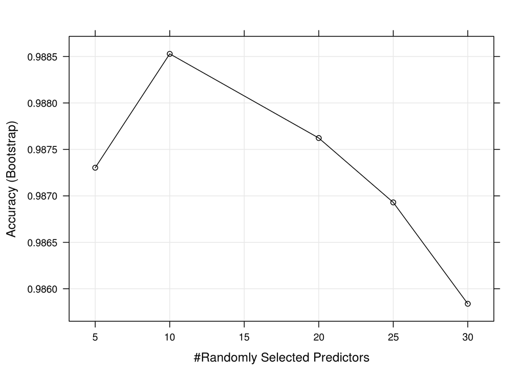

```r
## the RF model gives a very good accuracy of 0.988 on the training set
trellis.par.set(caretTheme())
plot(rf)
```

The tuning process chose a Random Forest with 10 random predictors as best performing. It already gives an outstanding accuracy of >0.95 on the training set.

## Evaluate model

```r
# predict on the validation set
predictions <- predict(rf, train_validation)

confusionMatrix(predictions, train_validation$classe)
```

```
## Confusion Matrix and Statistics
##
##           Reference
## Prediction    A    B    C    D    E
##          A 2232    8    0    0    0
##          B    0 1507    8    0    0
##          C    0    3 1358   17    1
##          D    0    0    2 1268    3
##          E    0    0    0    1 1438
##
## Overall Statistics
##
##                Accuracy : 0.9945
##                  95% CI : (0.9926, 0.996)
##     No Information Rate : 0.2845
##     P-Value [Acc > NIR] : < 2.2e-16
##
##                   Kappa : 0.9931
##  Mcnemar's Test P-Value : NA
##
## Statistics by Class:
##
##                      Class: A Class: B Class: C Class: D Class: E
## Sensitivity            1.0000   0.9928   0.9927   0.9860   0.9972
## Specificity            0.9986   0.9987   0.9968   0.9992   0.9998
## Pos Pred Value         0.9964   0.9947   0.9848   0.9961   0.9993
## Neg Pred Value         1.0000   0.9983   0.9985   0.9973   0.9994
## Prevalence             0.2845   0.1935   0.1744   0.1639   0.1838
## Detection Rate         0.2845   0.1921   0.1731   0.1616   0.1833
## Detection Prevalence   0.2855   0.1931   0.1758   0.1622   0.1834
## Balanced Accuracy      0.9993   0.9957   0.9947   0.9926   0.9985
```

On the train and validation set, the model performs exceptionally well - interestingly, it performs even better on the validation set than the set it was trained on. Also, all classes seem to be more or less equally well predicted (all measures over 0.95). Jackpot!

## Predict test cases for quiz

```r
# now the model is evaluated on the final test set with 20 test cases
predictions <- predict(rf, test)

predictions
```

```
##  [1] B A B A A E D B A A B C B A E E A B B B
## Levels: A B C D E
```